# Historical and Conceptual Background

Ronan Ysebaert

2023-10-31

# Conceptual background

## A long-term policy need: Measuring territorial inequalities in Europe (1954-2014)

It is impossible to understand the origin of the implementation of the MTA package without taking into account the specificities of spatial planning in Europe and the **need of monitoring tools and methods for measuring inequalities in Europe**: Early the question of measurement of territorial inequalities has been raised by planners and policy makers. Without being exhaustive, let us remind from a political point of view some usages of statistics and cartography regarding the measure of territorial inequalities in a European context.

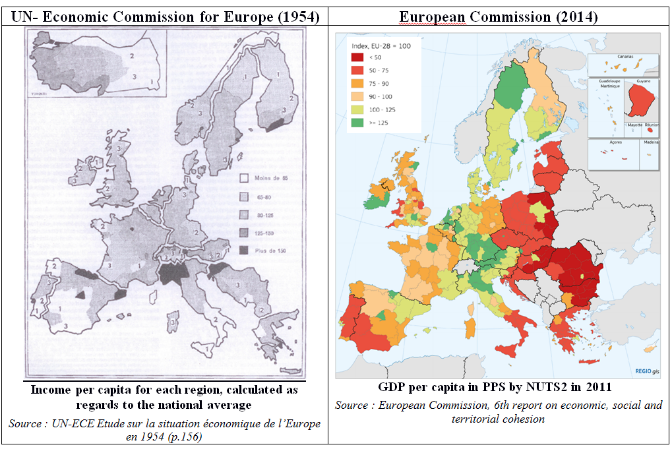

The first in-depth thought on regional inequalities from a geographical point of view in Europe came between the declaration of Schuman the 9th May 1950, which launch the European Coal and Steel Community; and the Rome treaty, which gives rise to the Economic European Union the 25th March 1957: in 1955 the *Commission économique pour l’Europe des Nations Unies (UNECE)* launched a study (Nations Unies 1955) on economic inequalities within several countries of Europe. Led by its Secretary General, the future Nobel Prize Gunnar Myrdal, this report foreshadows the future policies of the European Union and forthcoming regional analysis of OECD: lagging regions are identified and the reasons of the development gaps tried to be explained. Thus, “winning factors” were specified: distance to population or production centers, geographical situation of regions (peripheral or not), modernity and productivity of economic structures, demographic dynamics, etc.

It is interesting to note that the statistic criteria used to measure territorial inequalities was in this study the deviation of each region to its country of belonging, and not to the overall study area (European Union in this case). The solution proposed to solve inequalities was consequently not to identify federalist actions of solidarity at continental level. It was more directly to propose some tools for coordinating national policies and developing a comparative framework on causes and effects of territorial inequalities. Then, it is dependent to the sovereign countries to draw conclusions for implementing support policies for lagging territories. This approach is in fact very close to the issues raised in 1948 for managing the funds of the Marshall Plan. And it is not surprising to remark that the emergence of the main national policies in spatial planning started during the same period in France (creation of the DATAR in 1963), in Italy *(Casa del Mezzogiorno*, 1950) or in Germany (creation of the *Bundesministerium für Wohnungswesen, Städtebau une Raumordnung* in 1961). In all these cases, data availability, adapted statistics and maps were and remind especially useful to support and foresee spatial planning policies.

On the opposite of the pioneer map of Myrdal (map on the left), which supported a research on the causes of income inequalities and the possibilities existing to reduce them in a Keynesian framework of internal redistribution, the map proposed by the European Commission in 2014 (map on the right) is totally driven by the regional policy reglementation of the European Union (European Commission and Directorate-General for Regional and Urban Policy 2015). This maps leads the allocation of the main funds of the EU regional policy: The statistics criteria used to measure territorial inequalities is the Gross Domestic Product in PPS at NUTS2 level. This indicator is chosen to define eligible regions to the EU cohesion policy (GDP per capita under 75 % of the average of the European Union). In this case and in a very normative aspect, the measure of the deviation to a territorial context of reference (the European Union) is used to apply European policies and deliver a significant amount of funds (182 billion Euros dedicated to “less developed regions”, e.g. under 75 % of the EU average).

The analysis of these two maps reveals several possibilities for measuring territorial inequalities and display it on maps. It highlights also the important need - whatever the period considered - to define an adapted methodology to measure regional inequalities (Böhm and Schön 2004; Grasland 2004; Dubois et al. 2007).

Nowadays, the need to measure territorial disparities at lower scales become more and more important. The historical planning issues managed at national level is in a large extent transferred to regions and local authorities. To act locally, these new territories of governance requires statistical evidences to understand the structure and the dynamics of their territories. As displayed below, a lot of urban agencies and experts financed by public funds were recently created to provide local pictures of local dynamics (Metropole du Grand Paris, Metropole du Grand Lyon, Greater London, etc.). Here again, the need of territorial information is high.

[figure not shown]

## Conceptualization of the MTA analysis in this context

The MTA methodology has been set up in this context during the years 2000’s (Grasland 1997; Grasland et al. 2005). It has been initiated by the HyperCarte research group, which associate 4 research teams in geography and computer science. A major output coming from this research group was HyperAtlas, a Java application for the multiscalar territorial analysis (MTA). This tool has been developed by engineers in informatics (Martin 2004; Thomas 2008; Le Rubrus 2011) with the support of several European institutions within research projects (DG REGIO, ESPON, European Environmental Agency, European Parliament).

The basic idea behind the HyperAtlas and the MTA concept is that there is never a single and objective way to display a social phenomena on maps, but an infinity. It depends on the hypothesis made by the analyst regarding the contacts that can exist between individuals across the space and the time, regarding the influence of institutions within their territory of authority or for monitoring territorial impacts of policy measures.

MTA methods have been developed in order to highlight in a simple way such situation for hierarchical territorial divisions (Ysebaert et al. 2012). Territorial hierarchy is considered as a strict nesting of territories, for instance:

- In Europe: NUTS3 regions (basic territorial units) can be merged in NUTS2, NUTS1 or NUTS0 regions (possible territorial contexts), and merged for the all European Union (global context, study area).
- In France: Municipalities (basic territorial units) can be merged in *zones d’emploi*, *départements* or *régions* (possible territorial contexts), and merged for France as a whole (global context, study area).
- In Ile-de-France: *IRIS* or municipalities (basic territorial units) can be merged in *Établissements Publics Territoriaux* or *départements* (possible territorial contexts), and merged for all the region (global context, study area).

The central hypothesis behind the MTA consists to consider that the meaning of a statistical indicator always depends on territorial context of reference. Taking a concrete example, knowing that the Gross Domestic Product in 2008 of Nord-Pas-de-Calais is 24 700 euros per capita provides few information itself. It is rather interesting to understand how this region stands as regard to the European Union average (22 800 euros, + 7,7 %), to its country of belonging (France, 30 400 euros, - 18 %) or as compared to its neighboring regions (24 950 euros, - 1 %). The combination of these deviation measures allows to highlight regions in favorable situations, lagging regions and also to depict contradictory situations (e.g. a rich region in a poor country, and vice-versa).

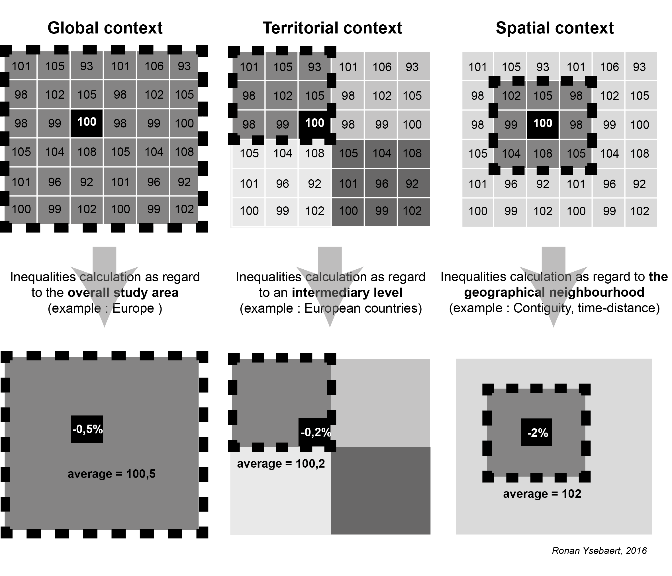

The originality of the methodology proposed by the HyperCarte research group is consequently to propose to compare in a same environment (HyperAtlas, or R with this package) several possibilities for measuring territorial inequality, according to three territorial contexts (global, territorial, spatial).

## Teams involved in the HyperCarte Research Group

The HyperCarte Research Group was founded in 1996 and has provided the main conceptual outputs proposed in this MTA package. It grouped in the period 1996-2015 four research teams from Paris (RIATE and Géographie-cités) and Grenoble (STeamer and Mescal):

- **UAR RIATE (UAR 2414)**: a team of engineers/geographers specialized in spatial analysis, cartography, tools development and database processing. It is the team who as created the MTA package and is in charge of its maintenance.
- **UMR Géographie-cités (UMR 8504)**: a team of researchers/geographers in the field of spatial analysis in the field of social phenomena.
- **LIG STeamer (UMR 5217)**: a team of computer scientists and engineers specialized in the processing of multimedia information with a temporal and spatial reference. The work of this team is validated by the development of operational platforms, web-application and frameworks.
- **LIG Mescal (UMR 5132)** : a team of computer scientists which aims at to design software solutions for the efficient exploitation of large distributed architectures at metropolitan, national and international levels.

# Resources

One of the major outputs of the HyperCarte Group was the development of [HyperAtlas](http://hypercarte.imag.fr/hyperatlas.html) - A Java application proposing a path of investigation for exploring MTA inequalities.

HyperAtlas has been used many times by the past, for pedagogical purpose (Pigaki and Leininger-Frézal 2014) or research activities in European Union (Ysebaert et al. 2012). The MTA methodology proposed by HyperAtlas has also been developed for decision making and monitoring in a policy context at EU : [ESPON Program](https://www.espon.eu/tools-maps/espon-2006-tools-espon-hyperatlas), European Parliament (Dubois et al. 2007) and national levels (Romania, Tunisia, Belgium, Cameroon, Nordic countries, France etc.).

The MTA methodology has been also followed for analyzing intra-urban voting geography at polling station level in Paris (Beauguitte and Lambert 2015).

In 2021, The ESPON Programme launched the update of the [ESPON HyperAtlas 3.0](https://www.espon.eu/HyperAtlas-3.0) *that is transparent, has a user-friendly interface with clear examples and storylines on how to use the tool and its resulting maps and graphs*. The resulting tool is called [Regico](https://regico.espon.eu/regico/tool).

The HyperAtlas solution is one way to access to multiscalar inequalities. The aim of the MTA package consists in proposing to the community **the main functionalities proposed by HyperAtlas in a R language**.

To understand how to use `MTA` functions and to interpret the results, you are invited to consult the [R Package vignette](https://CRAN.R-project.org/package=MTA/vignettes/MTA_Scenario.html), on income inequalities ; or the Rzine publication (Ysebaert and Grasland 2021) on employment inequalities.

# References

Beauguitte, Laurent, and Nicolas Lambert. 2015. “L’HyperAtlas électoral parisien (2007-2012) Un outil pour l’analyse des dynamiques électorales intra-urbaines.” *Mappe Monde*, May, 1–10. https://shs.hal.science/halshs-01155054.

Böhm, Kai, and Peter Schön. 2004. “ESPON 3.1 - Integrated Tools for European Spatial Development.” ESPON. https://www.espon.eu/programme/projects/espon-2006/integrated-tools-european-spatial-development.

Dubois, Alexandre, Erik Gløersen, Kaisa Lähteenmäki, Ole Damsgaard, Claude Grasland, Ronan Ysebaert, Christine Zanin, et al. 2007. “Les disparités régionales et la cohésion : quelles stratégies pour l’avenir?” Research Report. Parlement Européen ; Direction Générale des politiques internes de l’Union ; Département thématique B: politiques structurelles et de cohésion. https://hal.science/hal-03595697.

European Commission and Directorate-General for Regional and Urban Policy. 2015. *Investment for Jobs and Growth : Promoting Development and Good Governance in EU Regions and Cities : Sixth Report on Economic, Social and Territorial Cohesion*. Edited by L Dijkstra. Publications Office. https://doi.org/10.2776/15327.

Grasland, Claude. 1997. *A la recherche d’un cadre théorique et méthodologique pour l’étude des maillages territoriaux*. Colloque Les découpages du territoire, Lyon: Entretiens Jacques Cartier. http://census.web.ined.fr/debat/Contributions/Avant-Fevrier-1999/Grasland-2.html.

———. 2004. “Les inégalités régionales dans une Europe élargie.” In *Les incertitudes du grand élargissement : L’Europe centrale et balte dans l’intégration européenne*, 181–214.“Pays de l’est .” L’Harmattan. https://shs.hal.science/halshs-00175530.

Grasland, Claude, Hervé Martin, Jean-Marc Vincent, Jérôme Gensel, Hélène Mathian, Said Oulahal, Olivier Cuenot, Edi Euloge, and Liliane Lizzi. 2005. *Le projet Hypercarte : analyse spatiale et cartographie interactive*. Edited by T. Libourel D. Josselin. Colloque International de Géomatique et d’Analyse Spatiale, Avignon: SAGEO. http://hypercarte.imag.fr/SAGEO2005Hypercarte.pdf.

Le Rubrus, Benoit. 2011. “Cartographie et analyse territoriale multiscalaire. Réingénierie des logiciels HyperAtlas et HyperAdmin.” Master’s thesis, Conservatoire National des Arts et Métiers, Mémoire CNAM. http://hypercarte.imag.fr/MemoireCnam_BenoitLeRubrus_memoire_r163_201103061405_electro.pdf.

Martin, Philippe. 2004. “Interface cartographique pour l’analyse territoriale multiscalaire de phénomènes sociaux.” Master’s thesis, Conservatoire National des Arts et Métiers, Mémoire CNAM. http://hypercarte.imag.fr/CNAM_Philippe_Martin.pdf.

Nations Unies. 1955. *Etude Sur La Situation économique de l’europe En 1954, Comprenant Une étude Des Problèmes régionaux Dans Les Pays Européens Et Une étude Sur La Structure de l’économie Française*. Nations Unies. Départ. Des Affaires économiques ... Pour l’europe. N.U.

Pigaki, Maria, and Caroline Leininger-Frézal. 2014. “Enseigner les disparités socio-spatiales avec HyperAtlas: le cas de l’Union Européenne.” *Didáctica Geográfica*, no. 15. https://hal.science/hal-01950206.

Thomas, Raphaël. 2008. “Evolutions d’outils dédiés à l’analyse territoriale et à l’analyse spatiale dans le cadre du projet HyperCarte.” Master’s thesis, Conservatoire National des Arts et Métiers, Mémoire CNAM. http://hypercarte.imag.fr/Memoire_CNAM_RaphaelTHOMAS_13052008.pdf.

Ysebaert, Ronan, and Claude Grasland. 2021. “Analyse Territoriale Multiscalaire.” FR2007 CIST.

Ysebaert, Ronan, Nicolas Lambert, Claude Grasland, Benoit Le Rubrus, Marlène Villanova-Oliver, Jérôme Gensel, and Christine Plumejeaud. 2012. “HyperAtlas, un outil scientifique au service du débat politique - Application à la politique de cohésion de l’Union Européenne.” In *Fonder les sciences du territoire*, edited by Pierre Beckouche, Claude Grasland, and France Guérin-Pace & Jean-Yves Moisseron, 243–67. Collection Du CIST. Éditions Karthala. https://hal.science/hal-00954933.